# Notebook

- Nom et Prenom : Abdo Mirgan
- Groupe : 5

## Objectif :

- Flowchart
- Table 1
- Tableau 2
- Figure

```python
import polars as pl
import pandas as pd
from tableone import TableOne
import numpy as np
import math
from scipy import stats
import matplotlib.pyplot as plt
import re
import scipy.stats as stats
```

```python
import os
os.getcwd()
```

```
'c:\\Users\\Abdo\\OneDrive\\Desktop\\M1\\Data Challenge 1\\Projet\\Table1&2&Figure'
```

# 0. Flowchart

### 0.1 Sujet Screening , non eligible et eligible a la randomisation

#### === 0.1.1 Charger les fichiers ===

```python
# import os
# os.getcwd()

# === 1. Charger les fichiers ===
dm_in = pl.read_csv("../db/dm1.csv")   # Démographie
dm_out =pl.read_csv("../db/dm2.csv")
ds_in = pl.read_csv("../db/ds1.csv")   # Inclusion/Exclusion
ds_out = pl.read_csv("../db/ds2.csv")   # Disposition (facultatif)

dm_in.sample(n=1)
```

shape: (1, 20)

| STUDYID str | DOMAIN str | USUBJID str | EPOCH str | VISIT str | VISITNUM i64 | RFSTDTC i64 | RFENDTC i64 | SITEID str | BRTHDTC i64 | AGE str | AGEU str | SEX str | RACE str | ETHNIC str | ARMCD str | ARM str | COUNTRY str | DMDTC i64 | DMDY str |
| --- | --- | --- | --- | --- | --- | --- | --- | --- | --- | --- | --- | --- | --- | --- | --- | --- | --- | --- | --- |
| "NIDA-CTN-0001" | "DM" | "01_041193" | "SCREENING" | "BASELINE, ANY DAY PRIOR TO FIR… | 0 | 2001 | 2001 | null | 1966 | "35.671457906" | "YEARS" | "M" | "SPANISH, HISPANIC, OR LATINO" | "HISPANIC" | "CLON" | "CLONIDINE" | "USA" | 2001 | "-1" |

#### === 0.1.2 Phase Screening ===

```python
# IN
in_counts = dm_in["ARMCD"].value_counts()
print(in_counts)
print("Total des patients IN :", in_counts["count"].sum())

# OUT
out_counts = dm_out["ARMCD"].value_counts()
print(out_counts)
print("Total des patients OUT :", out_counts["count"].sum())
```

```
shape: (3, 2)
┌─────────┬───────┐
│ ARMCD   ┆ count │
│ ---     ┆ ---   │
│ str     ┆ u32   │
╞═════════╪═══════╡
│ SCRFAIL ┆ 25    │
│ BUPNAL  ┆ 77    │
│ CLON    ┆ 36    │
└─────────┴───────┘
Total des patients IN : 138
shape: (3, 2)
┌─────────┬───────┐
│ ARMCD   ┆ count │
│ ---     ┆ ---   │
│ str     ┆ u32   │
╞═════════╪═══════╡
│ CLON    ┆ 74    │
│ BUPNAL  ┆ 156   │
│ SCRFAIL ┆ 43    │
└─────────┴───────┘
Total des patients OUT : 273
```

```python
total_in= in_counts["count"].sum()
total_out= out_counts["count"].sum()
total_screnning = total_in + total_out
print("Total général des patients en screening :", total_screnning)
```

```
Total général des patients en screening : 411
```

#### === 0.1.3 Phase Randomization ===

```python
# Concaténer IN + OUT
dm_all = pl.concat([dm_in, dm_out])
# Garder seulement les randomisés
arms=["BUPNAL", "CLON"]
dm_rand=dm_all.filter(pl.col("ARMCD").is_in(arms))
print("Total sujets randomizer :", dm_rand.shape[0])
```

```
Total sujets randomizer : 343
```

```python
# Tableau pivoté des randomisés IN / OUT par bras
rand_pivot = (
    dm_rand
    .group_by(["ARMCD", "STUDYID"])
    .count()
    .pivot(values="count", index="ARMCD", columns="STUDYID")
    .rename({"NIDA-CTN-0001": "IN", "NIDA-CTN-0002": "OUT"})
)

# Ajouter le total par bras
rand_pivot_total = rand_pivot.with_columns(
    (pl.col("IN") + pl.col("OUT")).alias("Total_bras")
)

rand_pivot_total
```

shape: (2, 4)

| ARMCD str | OUT u32 | IN u32 | Total_bras u32 |
| --- | --- | --- | --- |
| "CLON" | 74 | 36 | 110 |
| "BUPNAL" | 156 | 77 | 233 |

```python
# Filtrer les non-randomisés
dm_non_rand = dm_all.filter(~pl.col("ARMCD").is_in(arms))

# Tableau pivoté IN / OUT
non_rand_pivot = (
    dm_non_rand
    .group_by(["ARMCD", "STUDYID"])
    .count()
    .pivot(values="count", index="ARMCD", columns="STUDYID")
    .fill_null(0)
)

# Ajouter le total par bras
non_rand_pivot_total = non_rand_pivot.with_columns(
    (pl.col("NIDA-CTN-0001") + pl.col("NIDA-CTN-0002")).alias("Total_bras")
)

non_rand_pivot_total
```

shape: (1, 4)

| ARMCD str | NIDA-CTN-0002 u32 | NIDA-CTN-0001 u32 | Total_bras u32 |
| --- | --- | --- | --- |
| "SCRFAIL" | 43 | 25 | 68 |

## 0.2 Sujet ayant abondonner dans la phase active ( Study day & follow up )

#### === 0.2.1 Abondant en phase study day ===

```python
# Concaténation disposition
DS = pl.concat([ds_in, ds_out])

# Filtrer les abandons avant la fin de la phase active (Study Day < 14)
ds_abandon_sd = DS.filter(
    (pl.col("EPOCH") != "SCREENING") &
    (pl.col("VISITNUM") < 14) &
    (pl.col("DSDECOD") != "PARTICIPANT COMPLETED ACTIVE PHASE OF STUDY")
)

# Garder une seule ligne par patient
ds_abandon_sd = ds_abandon_sd.unique(subset=["USUBJID"])
# Joindre avec DM pour récupérer le bras
ds_abandon_sd = ds_abandon_sd.join(
    dm_rand,
    on="USUBJID",
    how="inner"
)

# Compter les abandons par bras
abandon_sd_count = ds_abandon_sd.select(pl.col("ARMCD").value_counts())

print(abandon_sd_count)
```

```
shape: (2, 1)
┌───────────────┐
│ ARMCD         │
│ ---           │
│ struct[2]     │
╞═══════════════╡
│ {"CLON",19}   │
│ {"BUPNAL",14} │
└───────────────┘
```

```python
# Pivot IN / OUT des abandons Study Day < 14
abandon_sd_pivot = (
    ds_abandon_sd
    .group_by(["ARMCD", "STUDYID"])
    .count()
    .pivot(values="count", index="ARMCD", columns="STUDYID")
    .fill_null(0)
)

# Renommer les colonnes IN / OUT
abandon_sd_pivot = abandon_sd_pivot.rename({
    "NIDA-CTN-0001": "IN",
    "NIDA-CTN-0002": "OUT"
})

# Ajouter la colonne Total_bras
abandon_sd_total = abandon_sd_pivot.with_columns(
    (pl.col("IN") + pl.col("OUT")).alias("Total_bras")
)

abandon_sd_total
```

shape: (2, 4)

| ARMCD str | IN u32 | OUT u32 | Total_bras u32 |
| --- | --- | --- | --- |
| "CLON" | 15 | 4 | 19 |
| "BUPNAL" | 6 | 8 | 14 |

#### === 0.2.2 Abondant en phase follow up ===

```python
# Filtrer les abandons en follow-up (VISITNUM ≥ 15)
ds_fu_abandon = DS.filter(
    (pl.col("VISITNUM") > 14) &
    (pl.col("DSDECOD") != "PARTICIPANT COMPLETED ACTIVE PHASE OF STUDY")
)

# Garder une seule ligne par patient
ds_fu_abandon = ds_fu_abandon.unique(subset=["USUBJID"])

# Joindre pour récupérer le bras randomisé
ds_fu_abandon = ds_fu_abandon.join(
    dm_rand,
    on="USUBJID",
    how="inner"
)

# Compter les abandons follow-up par ARM
fu_abandon_count = ds_fu_abandon.select(pl.col("ARMCD").value_counts())

print(fu_abandon_count)
```

```
shape: (2, 1)
┌───────────────┐
│ ARMCD         │
│ ---           │
│ struct[2]     │
╞═══════════════╡
│ {"CLON",60}   │
│ {"BUPNAL",95} │
└───────────────┘
```

```python
# Pivot IN / OUT des abandons follow-up
fu_abandon_pivot = (
    ds_fu_abandon
    .group_by(["ARMCD", "STUDYID"])
    .count()
    .pivot(values="count", index="ARMCD", columns="STUDYID")
    .fill_null(0)
)

# Renommer IN / OUT
fu_abandon_pivot = fu_abandon_pivot.rename({
    "NIDA-CTN-0001": "IN",
    "NIDA-CTN-0002": "OUT"
})

# Ajouter Total par bras
fu_abandon_total = fu_abandon_pivot.with_columns(
    (pl.col("IN") + pl.col("OUT")).alias("Total_bras")
)

fu_abandon_total
```

shape: (2, 4)

| ARMCD str | OUT u32 | IN u32 | Total_bras u32 |
| --- | --- | --- | --- |
| "BUPNAL" | 59 | 36 | 95 |
| "CLON" | 40 | 20 | 60 |

## 0.3 Analyse en intention de traiter (ITT )

```python
# Tous les randomisés sont analysés, même s’ils ont abandonné.
print(rand_pivot_total)
```

```
shape: (2, 4)
┌────────┬─────┬─────┬────────────┐
│ ARMCD  ┆ OUT ┆ IN  ┆ Total_bras │
│ ---    ┆ --- ┆ --- ┆ ---        │
│ str    ┆ u32 ┆ u32 ┆ u32        │
╞════════╪═════╪═════╪════════════╡
│ CLON   ┆ 74  ┆ 36  ┆ 110        │
│ BUPNAL ┆ 156 ┆ 77  ┆ 233        │
└────────┴─────┴─────┴────────────┘
```

## 0.4 Analyse Per Protocol (PP)

##### Le PP inclut uniquement :

- ✔ les patients randomisés
- ✔ qui ont reçu le traitement selon le protocole
- ✔ qui ont completé la période nécessaire pour évaluer le critère principal
- ✔ qui n’ont pas abandonné, ni été perdus, ni eu d’écart majeur au protocole

PPbras= ITTbras−Abandons StudyDay<14bras

Selon le protocole, le critère de jugement principal est : Compléter les 13 jours de détoxification ET avoir un dernier test urinaire négatif aux opiacés le jour 13 ou 14. Parce que le PP évalue l’efficacité "réelle" du traitement.

```python
#ITT bras , Abandons StudyDay<14bras
rand_pivot_total, abandon_sd_total
```

```
(shape: (2, 4)
 ┌────────┬─────┬─────┬────────────┐
 │ ARMCD  ┆ OUT ┆ IN  ┆ Total_bras │
 │ ---    ┆ --- ┆ --- ┆ ---        │
 │ str    ┆ u32 ┆ u32 ┆ u32        │
 ╞════════╪═════╪═════╪════════════╡
 │ CLON   ┆ 74  ┆ 36  ┆ 110        │
 │ BUPNAL ┆ 156 ┆ 77  ┆ 233        │
 └────────┴─────┴─────┴────────────┘,
 shape: (2, 4)
 ┌────────┬─────┬─────┬────────────┐
 │ ARMCD  ┆ IN  ┆ OUT ┆ Total_bras │
 │ ---    ┆ --- ┆ --- ┆ ---        │
 │ str    ┆ u32 ┆ u32 ┆ u32        │
 ╞════════╪═════╪═════╪════════════╡
 │ CLON   ┆ 15  ┆ 4   ┆ 19         │
 │ BUPNAL ┆ 6   ┆ 8   ┆ 14         │
 └────────┴─────┴─────┴────────────┘)
```

```python
pp_in_out = (
    rand_pivot_total          # Tableau ITT
    .join(
        abandon_sd_total,     # Tableau abandons SD<14
        on="ARMCD",
        how="left",
        suffix="_abandon"
    )
    .with_columns([
        # Calcul PP_IN = IN_ITT – IN_abandons_SD
        (pl.col("IN") - pl.col("IN_abandon").fill_null(0)).alias("PP_IN"),

        # Calcul PP_OUT = OUT_ITT – OUT_abandons_SD
        (pl.col("OUT") - pl.col("OUT_abandon").fill_null(0)).alias("PP_OUT"),

        # Total PP
        ((pl.col("IN") - pl.col("IN_abandon").fill_null(0)) +
         (pl.col("OUT") - pl.col("OUT_abandon").fill_null(0))).alias("Total_PP")
    ])
    .select(["ARMCD", "PP_IN", "PP_OUT", "Total_PP"])
)

pp_in_out
```

shape: (2, 4)

| ARMCD str | PP_IN u32 | PP_OUT u32 | Total_PP u32 |
| --- | --- | --- | --- |
| "CLON" | 21 | 70 | 91 |
| "BUPNAL" | 71 | 148 | 219 |

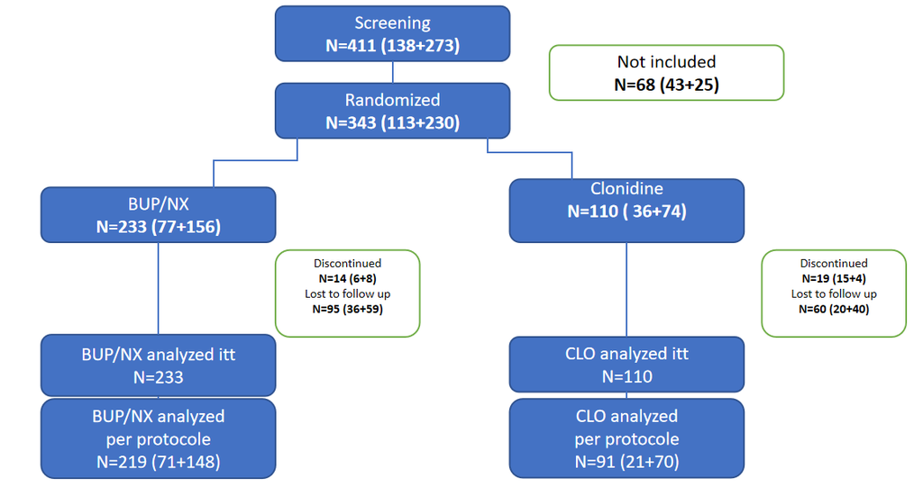

## 1. Table 1 descriptive des caractéristiques de la population étudiée à l'inclusion (baseline)

## 1.1 Importation des dataset et concatination avec polars (Je pense que je prefere polars par rapport a pandas)

## 1.2 Variable Demographique

```python
## DM : Demographie
# Variable demo :
    # GENDER (form DM )
	# AGE (form DM )
	# ARM (form DM )
	# MARTIAL ( form SC )
	# EDUCYRS ( form SC )
	# EMPLOYMENT (form SC )
	# BMI (form VS)
dm1 = pl.read_csv("../db/dm1.csv")   # Démographie
dm2 =pl.read_csv("../db/dm2.csv")
DM = pl.concat([dm1, dm2], how="vertical")
```

```python
# Liste des variables representatif des la démographie et identifiant du patient
dm_variables=["STUDYID","USUBJID","ARMCD","AGE","SEX","RACE","BRTHDTC"]
DM=DM.select(pl.col(dm_variables))
print(DM.columns)
print(DM.shape)
print(DM.sample(n=2))
```

```
['STUDYID', 'USUBJID', 'ARMCD', 'AGE', 'SEX', 'RACE', 'BRTHDTC']
(411, 7)
shape: (2, 7)
┌───────────────┬───────────┬───────┬──────────────┬─────┬──────────────────────────────┬─────────┐
│ STUDYID       ┆ USUBJID   ┆ ARMCD ┆ AGE          ┆ SEX ┆ RACE                         ┆ BRTHDTC │
│ ---           ┆ ---       ┆ ---   ┆ ---          ┆ --- ┆ ---                          ┆ ---     │
│ str           ┆ str       ┆ str   ┆ str          ┆ str ┆ str                          ┆ i64     │
╞═══════════════╪═══════════╪═══════╪══════════════╪═════╪══════════════════════════════╪═════════╡
│ NIDA-CTN-0002 ┆ 02_054920 ┆ CLON  ┆ 48.153319644 ┆ M   ┆ WHITE                        ┆ 1953    │
│ NIDA-CTN-0001 ┆ 01_077274 ┆ CLON  ┆ 61.281314168 ┆ M   ┆ SPANISH, HISPANIC, OR LATINO ┆ 1940    │
└───────────────┴───────────┴───────┴──────────────┴─────┴──────────────────────────────┴─────────┘
```

### Nous avions bien 411 sujet dans l'etude au baseline (Voir code flowchart)

#### Recuperer le information d education , martial et emploie depuis la table SC et l ajouter à notre table DM (Demographique)

```python
SC1=pl.read_csv("../db/sc1.csv")
SC2=pl.read_csv("../db/sc2.csv")

SC = pl.concat([SC1, SC2], how="vertical")
```

```python
SC.select("SCTESTCD").unique().sort("SCTESTCD")
```

shape: (5, 1)

| SCTESTCD str |
| --- |
| "ALLINCL" |
| "EDUCYRS" |
| "EMPLOY30" |
| "EMPLOY3Y" |
| "MARITAL" |

```python
variableSC_DM = ["EDUCYRS", "MARITAL", "EMPLOY30"]
SC=SC.filter(pl.col("SCTESTCD").is_in(variableSC_DM))
SC=SC.select(pl.col("USUBJID"),
             pl.col('SCTESTCD'),
             pl.col("SCORRES"))
SC.sample(n=3)
```

shape: (3, 3)

| USUBJID str | SCTESTCD str | SCORRES str |
| --- | --- | --- |
| "01_005053" | "EDUCYRS" | "12" |
| "02_012721" | "EMPLOY30" | "UNEMPLOYED" |
| "01_028279" | "EDUCYRS" | "12" |

```python
# Pivot : long -> wide (1 ligne par patient)
SC=SC.pivot(
    index="USUBJID",
    columns="SCTESTCD",
    values="SCORRES",

)
SC.sample(n=3)
```

shape: (3, 4)

| USUBJID str | EDUCYRS str | EMPLOY30 str | MARITAL str |
| --- | --- | --- | --- |
| "02_059903" | "12" | "FULL TIME (35+ HRS/WK)" | "NEVER MARRIED" |
| "01_050242" | "12" | "UNEMPLOYED" | "NEVER MARRIED" |
| "02_099368" | "11" | "UNEMPLOYED" | "NEVER MARRIED" |

```python
DM_SC= DM.join(SC, on="USUBJID", how="left")
DM_SC.sample(n=3)
```

shape: (3, 10)

| STUDYID str | USUBJID str | ARMCD str | AGE str | SEX str | RACE str | BRTHDTC i64 | EDUCYRS str | EMPLOY30 str | MARITAL str |
| --- | --- | --- | --- | --- | --- | --- | --- | --- | --- |
| "NIDA-CTN-0002" | "02_056472" | "CLON" | "51.09650924" | "M" | "BLACK, AFRICAN AMERICAN, OR NE… | 1950 | "14" | "RETIRED/DISABILITY" | "SEPARATED" |
| "NIDA-CTN-0002" | "02_064002" | "BUPNAL" | "51.603011636" | "M" | "WHITE" | 1949 | "14" | "FULL TIME (35+ HRS/WK)" | "NEVER MARRIED" |
| "NIDA-CTN-0002" | "02_058212" | "BUPNAL" | "35.1321013" | "F" | "WHITE" | 1966 | "10" | "UNEMPLOYED" | "DIVORCED" |

```python
DM_SC = DM_SC.with_columns([
    # Nettoyer AGE
    pl.col("AGE")
        .str.strip_chars()                        # enlever les espaces
        .replace("", None)                    # remplacer vide par null
        .cast(pl.Float64, strict=False)       # convertir, sans planter
        .alias("AGE"),

    # Nettoyer EDUCYSR
    pl.col("EDUCYRS")
        .str.strip_chars()
        .replace("", None)
        .cast(pl.Float64, strict=False)
        .alias("EDUCYRS")
])
DM_SC.sample(n=3)
```

shape: (3, 10)

| STUDYID str | USUBJID str | ARMCD str | AGE f64 | SEX str | RACE str | BRTHDTC i64 | EDUCYRS f64 | EMPLOY30 str | MARITAL str |
| --- | --- | --- | --- | --- | --- | --- | --- | --- | --- |
| "NIDA-CTN-0001" | "01_018076" | "BUPNAL" | 26.376454 | "M" | "WHITE" | 1975 | 14.0 | "PART TIME (IRREGULAR DAYWORK)" | "NEVER MARRIED" |
| "NIDA-CTN-0002" | "02_030052" | "BUPNAL" | 48.517454 | "M" | "BLACK, AFRICAN AMERICAN, OR NE… | 1952 | 14.0 | "UNEMPLOYED" | "LEGALLY MARRIED" |
| "NIDA-CTN-0001" | "01_018415" | "BUPNAL" | 20.013689 | "F" | "WHITE" | 1981 | 12.0 | "UNEMPLOYED" | "NEVER MARRIED" |

#### Recuperer le poids et la taille dans la table VS pour creer le BMI et l ajouter à notre table DMO (Demographique)

```python
# Variable signe vitauxx :
	# DBP : Pression diastolique (mmHg)
	# SBP : Pression systolique (mmHg)
	# HEIGHT : taille
	# WEIGHT : poids
	# PULSE : fréquence cardiaque (heart rate)
	# RESP : Frequence respiratoire (/min)
	# TEMP : Temperature corporelle (F)

VS1 = pl.read_csv("../db/vs1.csv")   # Signe vitaux
VS2 =pl.read_csv("../db/vs2.csv")
VS= VS = pl.concat([VS1, VS2], how="vertical")
```

```python
mesure_anthro=["HEIGHT","WEIGHT"]
VS_BMI=VS.filter(pl.col("VSTESTCD").is_in(mesure_anthro))
print(VS_BMI.sample(n=3))
```

```
shape: (3, 19)
┌───────────────┬────────┬───────────┬───────────┬───┬───────────────────┬──────────┬───────┬──────┐
│ STUDYID       ┆ DOMAIN ┆ USUBJID   ┆ EPOCH     ┆ … ┆ VISIT             ┆ VISITNUM ┆ VSDTC ┆ VSDY │
│ ---           ┆ ---    ┆ ---       ┆ ---       ┆   ┆ ---               ┆ ---      ┆ ---   ┆ ---  │
│ str           ┆ str    ┆ str       ┆ str       ┆   ┆ str               ┆ i64      ┆ i64   ┆ i64  │
╞═══════════════╪════════╪═══════════╪═══════════╪═══╪═══════════════════╪══════════╪═══════╪══════╡
│ NIDA-CTN-0002 ┆ VS     ┆ 02_080565 ┆ SCREENING ┆ … ┆ BASELINE, ANY DAY ┆ 0        ┆ 2001  ┆ -1   │
│               ┆        ┆           ┆           ┆   ┆ PRIOR TO FIR…     ┆          ┆       ┆      │
│ NIDA-CTN-0001 ┆ VS     ┆ 01_096578 ┆ SCREENING ┆ … ┆ BASELINE, ANY DAY ┆ 0        ┆ 2001  ┆ -1   │
│               ┆        ┆           ┆           ┆   ┆ PRIOR TO FIR…     ┆          ┆       ┆      │
│ NIDA-CTN-0002 ┆ VS     ┆ 02_037966 ┆ SCREENING ┆ … ┆ BASELINE, ANY DAY ┆ 0        ┆ 2001  ┆ 1    │
│               ┆        ┆           ┆           ┆   ┆ PRIOR TO FIR…     ┆          ┆       ┆      │
└───────────────┴────────┴───────────┴───────────┴───┴───────────────────┴──────────┴───────┴──────┘
```

```python
VS_BMI.select(pl.col("VSTESTCD")).unique()
```

shape: (2, 1)

| VSTESTCD str |
| --- |
| "WEIGHT" |
| "HEIGHT" |

```python
VS_BMI=VS_BMI.select(pl.col("USUBJID"),
             pl.col('VSTESTCD'),
             pl.col("VSORRES"))
```

```python
VS_BMI.sample(n=3)
```

shape: (3, 3)

| USUBJID str | VSTESTCD str | VSORRES f64 |
| --- | --- | --- |
| "02_021463" | "HEIGHT" | 71.0 |
| "01_038734" | "WEIGHT" | 170.0 |
| "01_027631" | "HEIGHT" | 72.0 |

```python
# Pivot : long -> wide (1 ligne par patient)
VS_BMI_pivot=VS_BMI.pivot(
    index="USUBJID",
    columns="VSTESTCD",
    values="VSORRES",
    aggregate_function="mean"

)
VS_BMI_pivot.sample(n=3)
```

shape: (3, 3)

| USUBJID str | HEIGHT f64 | WEIGHT f64 |
| --- | --- | --- |
| "02_057815" | 64.0 | 121.0 |
| "02_066057" | 69.0 | 150.0 |
| "01_038386" | 76.0 | 205.0 |

```python
VS_BMI = VS_BMI_pivot.with_columns([
    # Conversion vers kg et mètres
    (pl.col("WEIGHT") * 0.453592).alias("weight_kg"),
    (pl.col("HEIGHT") * 0.0254).alias("height_m")
])

VS_BMI = VS_BMI.with_columns([
    (pl.col("weight_kg") / (pl.col("height_m") ** 2)).alias("BMI")
])

VS_BMI = VS_BMI.drop(["HEIGHT", "WEIGHT","weight_kg","height_m"])
VS_BMI.sample(n=2)
```

shape: (2, 2)

| USUBJID str | BMI f64 |
| --- | --- |
| "01_037378" | 17.852179 |
| "01_078258" | 27.036783 |

```python
DM_SC_BMI= DM_SC.join(VS_BMI, on="USUBJID", how="left")
DM_SC_BMI.sample(n=3)
```

shape: (3, 11)

| STUDYID str | USUBJID str | ARMCD str | AGE f64 | SEX str | RACE str | BRTHDTC i64 | EDUCYRS f64 | EMPLOY30 str | MARITAL str | BMI f64 |
| --- | --- | --- | --- | --- | --- | --- | --- | --- | --- | --- |
| "NIDA-CTN-0001" | "01_058930" | "SCRFAIL" | null | "U" | null | null | null | null | null | 25.104333 |
| "NIDA-CTN-0002" | "02_066131" | "BUPNAL" | 42.179329 | "M" | "SPANISH, HISPANIC, OR LATINO" | 1959 | 12.0 | "UNEMPLOYED" | "LEGALLY MARRIED" | 26.581059 |
| "NIDA-CTN-0002" | "02_057805" | "BUPNAL" | 49.130732 | "M" | "BLACK, AFRICAN AMERICAN, OR NE… | 1952 | 12.0 | "PART TIME (IRREGULAR DAYWORK)" | "DIVORCED" | 19.258449 |

## 1.3 Variables VS ( Signe vitaux )

```python
VS.sample(n=1)
```

shape: (1, 19)

| STUDYID str | DOMAIN str | USUBJID str | EPOCH str | VSSEQ i64 | VSTESTCD str | VSTEST str | VSCAT str | VSPOS str | VSORRES f64 | VSORRESU str | VSSTRESC f64 | VSSTRESN f64 | VSSTRESU str | VSBLFL str | VISIT str | VISITNUM i64 | VSDTC i64 | VSDY i64 |
| --- | --- | --- | --- | --- | --- | --- | --- | --- | --- | --- | --- | --- | --- | --- | --- | --- | --- | --- |
| "NIDA-CTN-0001" | "VS" | "01_059208" | "ACTIVE" | 51 | "TEMP" | "TEMPERATURE" | "VITAL SIGNS FORM" | "SITTING" | 97.8 | "F" | 97.8 | 97.8 | "F" | null | "STUDY DAY 8" | 8 | 2002 | 8 |

```python
# Voir les moments de VISIT
VS.select(pl.col("VISITNUM")).unique()
```

shape: (18, 1)

| VISITNUM i64 |
| --- |
| 6 |
| 3 |
| 0 |
| 15 |
| 12 |
| … |
| 2 |
| 11 |
| 8 |
| 14 |
| 5 |

```python
# Filtrer le VS pour ne rester que sur le VISIT = 0 qui represente le Baseline
VS=VS.filter(pl.col("VISITNUM")==0)
print(VS.shape)
VS.sample(2)
```

```
(3150, 19)
```

shape: (2, 19)

| STUDYID str | DOMAIN str | USUBJID str | EPOCH str | VSSEQ i64 | VSTESTCD str | VSTEST str | VSCAT str | VSPOS str | VSORRES f64 | VSORRESU str | VSSTRESC f64 | VSSTRESN f64 | VSSTRESU str | VSBLFL str | VISIT str | VISITNUM i64 | VSDTC i64 | VSDY i64 |
| --- | --- | --- | --- | --- | --- | --- | --- | --- | --- | --- | --- | --- | --- | --- | --- | --- | --- | --- |
| "NIDA-CTN-0002" | "VS" | "02_056472" | "SCREENING" | 2 | "SBP" | "SYSTOLIC BLOOD PRESSURE" | "VITAL SIGNS FORM" | "SITTING" | 120.0 | "MMHG" | 120.0 | 120.0 | "MMHG" | "Y" | "BASELINE, ANY DAY PRIOR TO FIR… | 0 | 2001 | -1 |
| "NIDA-CTN-0002" | "VS" | "02_002365" | "SCREENING" | 8 | "PULSE" | "PULSE" | "CLINICAL OPIATE WITHDRAWAL SCA… | "SITTING" | 69.0 | "BEATS/MINUTE" | 69.0 | 69.0 | "BEATS/MINUTE" | "Y" | "BASELINE, ANY DAY PRIOR TO FIR… | 0 | 2001 | 1 |

```python
VS.null_count()
```

shape: (1, 19)

| STUDYID u32 | DOMAIN u32 | USUBJID u32 | EPOCH u32 | VSSEQ u32 | VSTESTCD u32 | VSTEST u32 | VSCAT u32 | VSPOS u32 | VSORRES u32 | VSORRESU u32 | VSSTRESC u32 | VSSTRESN u32 | VSSTRESU u32 | VSBLFL u32 | VISIT u32 | VISITNUM u32 | VSDTC u32 | VSDY u32 |
| --- | --- | --- | --- | --- | --- | --- | --- | --- | --- | --- | --- | --- | --- | --- | --- | --- | --- | --- |
| 0 | 0 | 0 | 0 | 0 | 0 | 0 | 0 | 772 | 0 | 7 | 7 | 7 | 6 | 0 | 0 | 0 | 0 | 384 |

```python
# Voir les valeurs representatifs des signe vitaux dans VSTESTCD
VS.select("VSTESTCD").unique().sort("VSTESTCD")
```

shape: (7, 1)

| VSTESTCD str |
| --- |
| "DBP" |
| "HEIGHT" |
| "PULSE" |
| "RESP" |
| "SBP" |
| "TEMP" |
| "WEIGHT" |

```python
"""
# Liste des variables representatif des signes vitaux
vs_variables=["DBP","SBP","PULSE","RESP","TEMP"]

VS=VS.filter(pl.col("VSTESTCD").is_in(vs_variables))

# Pivot : long -> wide (1 ligne par patient)
VS_large=VS.pivot(
    index="USUBJID",
    columns="VSTESTCD",
    values="VSORRES",

)"""
```

```
'\n# Liste des variables representatif des signes vitaux \nvs_variables=["DBP","SBP","PULSE","RESP","TEMP"]\n\nVS=VS.filter(pl.col("VSTESTCD").is_in(vs_variables))\n\n# Pivot : long -> wide (1 ligne par patient)\nVS_large=VS.pivot(\n    index="USUBJID",\n    columns="VSTESTCD",\n    values="VSORRES"…
```

```python
'''# Verifier qu il y a plus 2 valeur pour tout les patients
doublons_global = (
    VS
    .group_by(["USUBJID", "VSTESTCD"])
    .len()
    .filter(pl.col("len") > 1)
)

doublons_global'''
```

```
'# Verifier qu il y a plus 2 valeur pour tout les patients \ndoublons_global = (\n    VS\n    .group_by(["USUBJID", "VSTESTCD"])\n    .len()\n    .filter(pl.col("len") > 1)\n)\n\ndoublons_global'
```

### Remarque

```python
# Voir les categorie de VSCAT
VS.select("VSCAT").unique()
```

shape: (3, 1)

| VSCAT str |
| --- |
| "PHYSICAL EXAMINATION FORM" |
| "VITAL SIGNS FORM" |
| "CLINICAL OPIATE WITHDRAWAL SCA… |

```python
VS.select("VSPOS").unique()
```

shape: (3, 1)

| VSPOS str |
| --- |
| "SITTING" |
| "STANDING" |
| null |

```python
# Formulaires pertinents
vs_forms = ["VITAL SIGNS FORM"]
# Séparation vitaux vs anthropométrie
m_vitaux = ["DBP", "SBP", "PULSE", "RESP", "TEMP"]
# Filtrer signes vitaux classiques (inclut VSPOS)
# HEIGHT et WEIGHT n’ont PAS de VSPOS ce qui pourrais les supprimer si on applique un filtre VSPOS
# Comme on a deja utiliser HEIGHT et  WEIGHT pour calculer le BMI , nous allons appliquer le filtre VSPOS.

VS_vitals = VS.filter(
    pl.col("VSTESTCD").is_in(m_vitaux)
    & pl.col("VSCAT").is_in(vs_forms)
    & (pl.col("VSPOS") == "SITTING")
)

# Corriger les doublons une mesure par patient (Ex : 1 SEULE PULSE )
VS_filtrage = (
    VS_vitals
    .group_by(["USUBJID", "VSTESTCD"])
    .agg(pl.col("VSORRES").cast(pl.Float64).first())
)

# Pivot final : Construit notre tables
VS_pivotage = VS_filtrage.pivot(
    index="USUBJID",
    on="VSTESTCD",
    values="VSORRES"
)


VS = VS_pivotage.select([
    pl.col("USUBJID"),
    pl.col("DBP").alias("diastol_mmHg"),
    pl.col("SBP").alias("systol_mmHg"),
    pl.col("PULSE").alias("battmnt/mn"),
    pl.col("RESP").alias("resp/minute"),
    ((pl.col("TEMP") - 32) * 5/9).alias("TEMP_C")
])


VS.sample(n=3)
```

shape: (3, 6)

| USUBJID str | diastol_mmHg f64 | systol_mmHg f64 | battmnt/mn f64 | resp/minute f64 | TEMP_C f64 |
| --- | --- | --- | --- | --- | --- |
| "02_039697" | 84.0 | 118.0 | 72.0 | 17.0 | 37.555556 |
| "02_083202" | 76.0 | 120.0 | 64.0 | 16.0 | 37.222222 |
| "01_017348" | 50.0 | 118.0 | 94.0 | 18.0 | 37.388889 |

```python
# Verifier qu il y a plus 2 valeur pour tout les patients
VS.group_by("USUBJID").count().filter(pl.col("count") > 1)
```

shape: (0, 2)

| USUBJID | count |
| --- | --- |
| str | u32 |

```python
#Voir valeurs manquante apres filtrage
print(VS_filtrage.null_count())
#Il y avais 0 valeurs manquante des parametre vitaux contenue dans VSORRES apres le filtrage
```

```
shape: (1, 3)
┌─────────┬──────────┬─────────┐
│ USUBJID ┆ VSTESTCD ┆ VSORRES │
│ ---     ┆ ---      ┆ ---     │
│ u32     ┆ u32      ┆ u32     │
╞═════════╪══════════╪═════════╡
│ 0       ┆ 0        ┆ 0       │
└─────────┴──────────┴─────────┘
```

```python
#Voir valeurs manquante apres pivotage
print(VS_pivotage.null_count())
#### Apres pivotage on observe des Valeurs Manquante alors qu au filtrage y avais pas .
# Le pivotage a creer des valeurs manquante , la cause est que chaque patient n’avais pas forcément toutes les 5 mesures.
```

```
shape: (1, 6)
┌─────────┬──────┬─────┬─────┬───────┬──────┐
│ USUBJID ┆ RESP ┆ SBP ┆ DBP ┆ PULSE ┆ TEMP │
│ ---     ┆ ---  ┆ --- ┆ --- ┆ ---   ┆ ---  │
│ u32     ┆ u32  ┆ u32 ┆ u32 ┆ u32   ┆ u32  │
╞═════════╪══════╪═════╪═════╪═══════╪══════╡
│ 0       ┆ 7    ┆ 0   ┆ 0   ┆ 1     ┆ 8    │
└─────────┴──────┴─────┴─────┴───────┴──────┘
```

```python
### Nous allons maintenant joindre la table VS avec DM_SC_BMI

DM_SC_BMI_VS= DM_SC_BMI.join(VS, on="USUBJID", how="left")
# Apres avoir joint la dataframe demographique avec celui de signes vitaux , nous avons toujours les 411 sujets , ce qui veut dire que notre jointure à été reussis
print(DM_SC_BMI_VS.shape)
DM_SC_BMI_VS.sample(n=3)
```

```
(411, 16)
```

shape: (3, 16)

| STUDYID str | USUBJID str | ARMCD str | AGE f64 | SEX str | RACE str | BRTHDTC i64 | EDUCYRS f64 | EMPLOY30 str | MARITAL str | BMI f64 | diastol_mmHg f64 | systol_mmHg f64 | battmnt/mn f64 | resp/minute f64 | TEMP_C f64 |
| --- | --- | --- | --- | --- | --- | --- | --- | --- | --- | --- | --- | --- | --- | --- | --- |
| "NIDA-CTN-0001" | "01_009365" | "BUPNAL" | 21.98768 | "F" | "WHITE" | 1979 | 13.0 | "STUDENT" | "NEVER MARRIED" | 23.344088 | 68.0 | 110.0 | 96.0 | 20.0 | 37.222222 |
| "NIDA-CTN-0002" | "02_092156" | "CLON" | 45.366188 | "M" | "SPANISH, HISPANIC, OR LATINO" | 1956 | 12.0 | "PART TIME (IRREGULAR DAYWORK)" | "NEVER MARRIED" | 25.985792 | 72.0 | 116.0 | 76.0 | 18.0 | 37.333333 |
| "NIDA-CTN-0002" | "02_020931" | "SCRFAIL" | null | "F" | "BLACK, AFRICAN AMERICAN, OR NE… | 1964 | 9.0 | "UNEMPLOYED" | "LIVING WITH PARTNER/COHABITATI… | 23.051443 | 74.0 | 120.0 | 69.0 | 12.0 | 36.666667 |

## 1.4 Variables Historique médical

```python
# Variable antecedant medicaux :
	# MHTERM : MEDICAL CONDITION
	# MHOCCUR : PAST HISTORY ( YES / NO )

mh1 = pl.read_csv("../db/mh1.csv")   # Antecedent médicaux
mh2 =pl.read_csv("../db/mh2.csv")
MH = pl.concat([mh1, mh2], how="vertical")
MH.sample(n=2)
```

shape: (2, 14)

| STUDYID str | DOMAIN str | USUBJID str | EPOCH str | MHSEQ i64 | MHSPID i64 | MHTERM str | MHOCCUR str | MHSTAT str | VISIT str | VISITNUM i64 | MHDTC i64 | MHDY i64 | MHENRF str |
| --- | --- | --- | --- | --- | --- | --- | --- | --- | --- | --- | --- | --- | --- |
| "NIDA-CTN-0002" | "MH" | "02_000549" | "SCREENING" | 6 | 3 | "CARDIOVASCULAR" | "N" | null | "BASELINE, ANY DAY PRIOR TO FIR… | 0 | 2001 | -8 | "DURING/AFTER" |
| "NIDA-CTN-0001" | "MH" | "01_037378" | "SCREENING" | 12 | 6 | "X-RAY POSITIVE FOR TB" | "N" | null | "BASELINE, ANY DAY PRIOR TO FIR… | 0 | 2001 | -1 | "DURING/AFTER" |

| Variable | Rôle |
| --- | --- |
| **USUBJID** | Identifiant patient |
| **MHTERM** | Nom de l’antécédent médical (Cardiovascular, Endocrine, Allergies…) |
| **MHOCCUR** | Y/N → indique si l’antécédent est présent |
| **MHENRF** | BEFORE / DURING → indique si c’est un antécédent avant traitement |
| **EPOCH / VISITNUM** | Période (SCREENING) — on garde uniquement *avant traitement* |

```python
MH0 = (
    MH.filter(
        (pl.col("VISITNUM") == 0) &
        (pl.col("MHENRF") == "BEFORE")
    )
)
MH0.sample(n=2)
```

shape: (2, 14)

| STUDYID str | DOMAIN str | USUBJID str | EPOCH str | MHSEQ i64 | MHSPID i64 | MHTERM str | MHOCCUR str | MHSTAT str | VISIT str | VISITNUM i64 | MHDTC i64 | MHDY i64 | MHENRF str |
| --- | --- | --- | --- | --- | --- | --- | --- | --- | --- | --- | --- | --- | --- |
| "NIDA-CTN-0002" | "MH" | "02_045563" | "SCREENING" | 20 | 11 | "GENITOURINARY" | "N" | null | "BASELINE, ANY DAY PRIOR TO FIR… | 0 | 2001 | -7 | "BEFORE" |
| "NIDA-CTN-0002" | "MH" | "02_081045" | "SCREENING" | 7 | 4 | "RESPIRATORY" | "N" | null | "BASELINE, ANY DAY PRIOR TO FIR… | 0 | 2001 | -9 | "BEFORE" |

```python
MH0=MH0.select(pl.col("USUBJID"),
               pl.col("MHTERM"),
               pl.col("MHOCCUR"))
MH0.sample(n=4)
```

shape: (4, 3)

| USUBJID str | MHTERM str | MHOCCUR str |
| --- | --- | --- |
| "01_018881" | "EYES, EARS, NOSE, AND THROAT" | "N" |
| "01_052001" | "TB SKIN TEST POSITIVE" | "N" |
| "02_035542" | "X-RAY POSITIVE FOR TB" | "N" |
| "02_012064" | "DERMATOLOGICAL" | "N" |

```python
MH0_pivot=MH0.pivot(
    index="USUBJID",
    on="MHTERM",
    values="MHOCCUR"
)
MH0_pivot
```

shape: (381, 18)

| USUBJID str | ALLERGIES str | CARDIOVASCULAR str | DERMATOLOGICAL str | ENDOCRINE str | EYES, EARS, NOSE, AND THROAT str | GASTROINTESTINAL str | GENITOURINARY str | HEPATIC str | MUSCULOSKELETAL str | NEUROLOGICAL str | OTHER str | PSYCHIATRIC str | RESPIRATORY str | SEIZURE str | SYMPTOMS OF TB str | TB SKIN TEST POSITIVE str | X-RAY POSITIVE FOR TB str |
| --- | --- | --- | --- | --- | --- | --- | --- | --- | --- | --- | --- | --- | --- | --- | --- | --- | --- |
| "01_000579" | "N" | "N" | "N" | "N" | "N" | "N" | "Y" | "N" | "N" | "Y" | "Y" | "Y" | "N" | "Y" | "N" | "N" | "N" |
| "01_001362" | "N" | "N" | "N" | "N" | "N" | "N" | "N" | "N" | "N" | "N" | "N" | "N" | "N" | "N" | "N" | "N" | "N" |
| "01_001490" | "N" | "N" | "N" | "N" | "N" | "N" | "N" | "N" | "N" | "N" | "N" | "N" | "N" | "N" | "N" | "N" | "N" |
| "01_002199" | "N" | "N" | "N" | "N" | "Y" | "N" | "N" | "Y" | "Y" | "N" | "Y" | "Y" | "N" | "N" | "N" | "N" | "N" |
| "01_002844" | "N" | "N" | "N" | "N" | "N" | "N" | "N" | "N" | "N" | "N" | null | "N" | "N" | "N" | "N" | "N" | "N" |
| … | … | … | … | … | … | … | … | … | … | … | … | … | … | … | … | … | … |
| "02_098074" | "N" | "Y" | "Y" | "N" | "N" | "N" | "N" | "Y" | "N" | "N" | null | "N" | "N" | "Y" | "N" | "N" | "N" |
| "02_098425" | "Y" | "N" | "Y" | "N" | "N" | "Y" | "N" | "N" | "N" | "N" | "N" | "N" | "N" | "N" | "N" | "N" | "N" |
| "02_099053" | "N" | "N" | "N" | "N" | "N" | "N" | "N" | "N" | "N" | "N" | "N" | "N" | "N" | "N" | null | null | null |
| "02_099368" | "N" | "N" | "N" | "N" | "N" | "N" | "N" | "N" | "N" | "N" | "N" | "N" | "N" | "N" | "N" | "N" | "N" |
| "02_099926" | "Y" | "N" | "N" | "N" | "N" | "N" | "N" | "N" | "N" | "N" | "Y" | "N" | "N" | "N" | "N" | "Y" | "Y" |

```python
DM_SC_BMI_VS_MH = DM_SC_BMI_VS.join(MH0_pivot, on="USUBJID", how="left")
DM_SC_BMI_VS_MH.sample(n=3)
```

shape: (3, 33)

| STUDYID str | USUBJID str | ARMCD str | AGE f64 | SEX str | RACE str | BRTHDTC i64 | EDUCYRS f64 | EMPLOY30 str | MARITAL str | BMI f64 | diastol_mmHg f64 | systol_mmHg f64 | battmnt/mn f64 | resp/minute f64 | TEMP_C f64 | ALLERGIES str | CARDIOVASCULAR str | DERMATOLOGICAL str | ENDOCRINE str | EYES, EARS, NOSE, AND THROAT str | GASTROINTESTINAL str | GENITOURINARY str | HEPATIC str | MUSCULOSKELETAL str | NEUROLOGICAL str | OTHER str | PSYCHIATRIC str | RESPIRATORY str | SEIZURE str | … |
| --- | --- | --- | --- | --- | --- | --- | --- | --- | --- | --- | --- | --- | --- | --- | --- | --- | --- | --- | --- | --- | --- | --- | --- | --- | --- | --- | --- | --- | --- | --- |
| "NIDA-CTN-0002" | "02_091708" | "CLON" | 55.978097 | "M" | "OTHER" | 1945 | 14.0 | "PART TIME (IRREGULAR DAYWORK)" | "DIVORCED" | 22.957355 | 89.0 | 150.0 | 64.0 | 14.0 | 36.777778 | "N" | "N" | "N" | "N" | "N" | "Y" | "N" | "N" | "N" | "N" | "N" | "N" | "N" | "N" | … |
| "NIDA-CTN-0001" | "01_074593" | "SCRFAIL" | null | "M" | "WHITE" | 1967 | 12.0 | "UNEMPLOYED" | "DIVORCED" | 29.757877 | 60.0 | 100.0 | 73.0 | 14.0 | 36.5 | "N" | "N" | "N" | "N" | "N" | "N" | "N" | "N" | "N" | "N" | "N" | "Y" | "N" | "N" | … |
| "NIDA-CTN-0001" | "01_065383" | "BUPNAL" | 43.115674 | "M" | "WHITE" | 1958 | 13.0 | "UNEMPLOYED" | "LIVING WITH PARTNER/COHABITATI… | 29.536646 | 86.0 | 136.0 | 84.0 | 20.0 | 36.111111 | "Y" | "N" | "N" | "N" | "N" | "Y" | "N" | "Y" | "N" | "N" | "N" | "N" | "N" | "N" | … |

## 1.5 Variables laboratoire

```python
# df laboratoire :

lb1 = pl.read_csv("../db/lb1.csv")   # Laboratory
lb2 =pl.read_csv("../db/lb2.csv")
LB = pl.concat([lb1, lb2], how="vertical")
```

```python
# Filtre baseline & echantillon
LB=LB.filter(pl.col("VISITNUM")==0)
LB.sample(n=2)
```

shape: (2, 27)

| STUDYID str | DOMAIN str | USUBJID str | EPOCH str | LBSEQ i64 | LBTESTCD str | LBTEST str | LBCAT str | LBORRES str | LBORRESU str | LBORNRLO str | LBORNRHI str | LBSTRESC str | LBSTRESN str | LBSTRESU str | LBSTNRLO str | LBSTNRHI str | LBNRIND str | LBSTAT str | LBREASND str | LBSPEC str | LBMETHOD str | LBBLFL str | VISIT str | VISITNUM i64 | LBDTC i64 | LBDY str |
| --- | --- | --- | --- | --- | --- | --- | --- | --- | --- | --- | --- | --- | --- | --- | --- | --- | --- | --- | --- | --- | --- | --- | --- | --- | --- | --- |
| "NIDA-CTN-0002" | "LB" | "02_092341" | "SCREENING" | 12 | "AMPHET" | "AMPHETAMINES" | "DRUG SCREEN" | "NEGATIVE" | null | null | null | "NEGATIVE" | " " | null | " " | " " | null | null | null | "URINE" | "CENTRAL LAB" | "Y" | "BASELINE, ANY DAY PRIOR TO FIR… | 0 | 2002 | "1" |
| "NIDA-CTN-0001" | "LB" | "01_081464" | "SCREENING" | 12 | "BENZOD" | "BENZODIAZEPINES" | "DRUG SCREEN" | "NEGATIVE" | null | null | null | "NEGATIVE" | " " | null | " " | " " | null | null | null | "URINE" | "CENTRAL LAB" | "Y" | "BASELINE, ANY DAY PRIOR TO FIR… | 0 | 2001 | "-1" |

Lors de l’analyse du domaine LB, nous avons observé que l’ensemble des tests urinaires n’était pas disponible dans les deux modalités d’analyse (LBMETHOD). Une exploration systématique par excels a montré :

- Tests disponibles en ACCUTEST (10 tests) Ces tests correspondent au panel immunologique rapide utilisé pour un retour immédiat des résultats
  - COCAINE
  - BENZOD
  - AMPHET,
  - METH,
  - METHADON,
  - TCA,
  - MORPHINE,
  - PCP,
  - THC,
  - BARBIT
- Tests disponibles en CENTRAL LAB (7 tests + 1 test non mappé) Analyses confirmatoires réalisées par le laboratoire central (valeurs officielles)
  - AMPHET,
  - COCAINE,
  - BENZOD,
  - OPIATE,
  - NONE,
  - CREAT,
  - THC,
  - METHADON

“Pour l’analyse du critère principal (retention), seuls les tests urinaires opioïdes ont été retenus. Le test OPIATE issu du laboratoire central a été utilisé en priorité. Le test MORPHINE, non disponible au laboratoire central, a été extrait à partir du panel ACCUTEST. Les autres substances ont été exclues de l’analyse

```python
#selectionner uniquement les colonnes necessaire dans le lb
LB0=LB.select(pl.col("USUBJID"),
              pl.col("LBTESTCD"),
              pl.col("LBORRES"),
              pl.col("LBMETHOD"),)
LB0.sample(n=3)
```

shape: (3, 4)

| USUBJID str | LBTESTCD str | LBORRES str | LBMETHOD str |
| --- | --- | --- | --- |
| "01_074593" | "CREAT" | "294.1" | "CENTRAL LAB" |
| "02_031579" | "AMPHET" | "NEGATIVE" | "ACCUTEST" |
| "02_019718" | "BENZOD" | "NEGATIVE" | "ACCUTEST" |

```python
LB_opioids = LB0.filter(
    (
        (pl.col("LBTESTCD") == "OPIATE") &
        (pl.col("LBMETHOD") == "CENTRAL LAB")
    ) |
    (
        (pl.col("LBTESTCD") == "MORPHINE") &
        (pl.col("LBMETHOD") == "ACCUTEST")
    )
)

LB_opioids = LB_opioids.group_by(
    ["USUBJID", "LBTESTCD"]
).agg(
    pl.col("LBORRES").first()
)
LB_opioids_wide = LB_opioids.pivot(
    index="USUBJID",
    on="LBTESTCD",
    values="LBORRES"
)

LB_opioids_wide.head()
```

shape: (5, 3)

| USUBJID str | OPIATE str | MORPHINE str |
| --- | --- | --- |
| "02_081773" | "POSITIVE" | "POSITIVE" |
| "02_065406" | "POSITIVE" | "POSITIVE" |
| "02_022945" | null | "POSITIVE" |
| "02_036130" | "POSITIVE" | "POSITIVE" |
| "01_034960" | "NEGATIVE" | "NEGATIVE" |

```python
# On obtient des valeurs manquante surtout au niveau OPIATE
LB_opioids_wide.null_count()
```

shape: (1, 3)

| USUBJID u32 | OPIATE u32 | MORPHINE u32 |
| --- | --- | --- |
| 0 | 70 | 1 |

- Dans l’article, le critère principal est basé sur l’absence de consommation opioïde, donc :
  - Un sujet est considéré POSITIF aux opioïdes si AU MOINS un test est positif
  - OPIOID_POS = (OPIATE == POSITIVE) OR (MORPHINE == POSITIVE)

Conclusion : La positivité opioïde a été définie comme positive si le test OPIATE du laboratoire central ou, à défaut, le test MORPHINE issu d’ACCUTEST était positif.

```python
LB_opioids_wide = LB_opioids_wide.with_columns(
    pl.when(
        (pl.col("OPIATE") == "POSITIVE") |
        (pl.col("MORPHINE") == "POSITIVE")
    )
    .then(pl.lit("POSITIVE"))
    .otherwise(pl.lit("NEGATIVE"))
    .alias("OPIOID_STATUS")
)
LB_opioids_wide
```

shape: (404, 4)

| USUBJID str | OPIATE str | MORPHINE str | OPIOID_STATUS str |
| --- | --- | --- | --- |
| "02_081773" | "POSITIVE" | "POSITIVE" | "POSITIVE" |
| "02_065406" | "POSITIVE" | "POSITIVE" | "POSITIVE" |
| "02_022945" | null | "POSITIVE" | "POSITIVE" |
| "02_036130" | "POSITIVE" | "POSITIVE" | "POSITIVE" |
| "01_034960" | "NEGATIVE" | "NEGATIVE" | "NEGATIVE" |
| … | … | … | … |
| "02_021137" | null | "POSITIVE" | "POSITIVE" |
| "02_098074" | null | "POSITIVE" | "POSITIVE" |
| "02_055918" | "POSITIVE" | "POSITIVE" | "POSITIVE" |
| "02_095071" | null | "POSITIVE" | "POSITIVE" |
| "02_095665" | null | "POSITIVE" | "POSITIVE" |

```python
# On à plus de valeurs manquante sur le critere principale
LB_opioids_wide.null_count()
```

shape: (1, 4)

| USUBJID u32 | OPIATE u32 | MORPHINE u32 | OPIOID_STATUS u32 |
| --- | --- | --- | --- |
| 0 | 70 | 1 | 0 |

```python
# Plus besoin de morphine et opiate
LB_final = LB_opioids_wide.select(
    ["USUBJID", "OPIOID_STATUS"]
)
LB_final
```

shape: (404, 2)

| USUBJID str | OPIOID_STATUS str |
| --- | --- |
| "02_081773" | "POSITIVE" |
| "02_065406" | "POSITIVE" |
| "02_022945" | "POSITIVE" |
| "02_036130" | "POSITIVE" |
| "01_034960" | "NEGATIVE" |
| … | … |
| "02_021137" | "POSITIVE" |
| "02_098074" | "POSITIVE" |
| "02_055918" | "POSITIVE" |
| "02_095071" | "POSITIVE" |
| "02_095665" | "POSITIVE" |

```python
LB_final.null_count()
```

shape: (1, 2)

| USUBJID u32 | OPIOID_STATUS u32 |
| --- | --- |
| 0 | 0 |

```python
### Nous allons maintenant joindre la table LB_final avec la dataframe demographique , signes vitaux etc..
DM_SC_BMI_VS_MH_LB= DM_SC_BMI_VS_MH.join(LB_final, on="USUBJID", how="left")
DM_SC_BMI_VS_MH_LB.sample(n=3)
```

shape: (3, 34)

| STUDYID str | USUBJID str | ARMCD str | AGE f64 | SEX str | RACE str | BRTHDTC i64 | EDUCYRS f64 | EMPLOY30 str | MARITAL str | BMI f64 | diastol_mmHg f64 | systol_mmHg f64 | battmnt/mn f64 | resp/minute f64 | TEMP_C f64 | ALLERGIES str | CARDIOVASCULAR str | DERMATOLOGICAL str | ENDOCRINE str | EYES, EARS, NOSE, AND THROAT str | GASTROINTESTINAL str | GENITOURINARY str | HEPATIC str | MUSCULOSKELETAL str | NEUROLOGICAL str | OTHER str | PSYCHIATRIC str | RESPIRATORY str | SEIZURE str | … |
| --- | --- | --- | --- | --- | --- | --- | --- | --- | --- | --- | --- | --- | --- | --- | --- | --- | --- | --- | --- | --- | --- | --- | --- | --- | --- | --- | --- | --- | --- | --- |
| "NIDA-CTN-0002" | "02_065163" | "BUPNAL" | 26.349076 | "M" | "WHITE" | 1975 | 9.0 | "UNEMPLOYED" | "NEVER MARRIED" | 22.239938 | 75.0 | 119.0 | 58.0 | 16.0 | 37.333333 | "Y" | "N" | "N" | "N" | "N" | "N" | "N" | "Y" | "N" | "N" | "N" | "Y" | "N" | "N" | … |
| "NIDA-CTN-0001" | "01_096723" | "CLON" | 44.999316 | "M" | "BLACK, AFRICAN AMERICAN, OR NE… | 1956 | 12.0 | "PART TIME (IRREGULAR DAYWORK)" | "NEVER MARRIED" | 23.479935 | 75.0 | 100.0 | 58.0 | 23.0 | 36.277778 | "N" | "N" | "N" | "N" | "N" | "Y" | null | "N" | "N" | "N" | null | "N" | "N" | "N" | … |
| "NIDA-CTN-0001" | "01_077269" | "BUPNAL" | 33.420945 | "M" | "OTHER" | 1968 | 12.0 | "PART TIME (IRREGULAR DAYWORK)" | "DIVORCED" | 20.343432 | 64.0 | 112.0 | 94.0 | 22.0 | 36.388889 | "Y" | "N" | "N" | "N" | "N" | "N" | "N" | "N" | "N" | "N" | "N" | "N" | "N" | "N" | … |

## 1.6 Choix des variables et separation en 2 Dataframe ( Hospitaliser & Ambulatoire ) pour la table one

```python
identifiant_groupe=["STUDYID","USUBJID","ARMCD"]
donnée_demo= ["AGE","SEX", "RACE", "BRTHDTC", "EDUCYRS", "EMPLOY30", "MARITAL", "BMI"]
donnée_signe_vitaux=["diastol_mmHg","systol_mmHg", "battmnt/mn", "resp/minute", "TEMP_C"]
donnée_labo=["OPIOID_STATUS"]
donnée_historique_medicale = [
    "CARDIOVASCULAR",
    "NEUROLOGICAL",
    "PSYCHIATRIC",

]

variables_table1 = (
    identifiant_groupe
    + donnée_demo
    + donnée_signe_vitaux
    + donnée_labo
    + donnée_historique_medicale
)
```

```python
df_table1 = DM_SC_BMI_VS_MH_LB.select(variables_table1)
df_table1.sample(n=2)
```

shape: (2, 20)

| STUDYID str | USUBJID str | ARMCD str | AGE f64 | SEX str | RACE str | BRTHDTC i64 | EDUCYRS f64 | EMPLOY30 str | MARITAL str | BMI f64 | diastol_mmHg f64 | systol_mmHg f64 | battmnt/mn f64 | resp/minute f64 | TEMP_C f64 | OPIOID_STATUS str | CARDIOVASCULAR str | NEUROLOGICAL str | PSYCHIATRIC str |
| --- | --- | --- | --- | --- | --- | --- | --- | --- | --- | --- | --- | --- | --- | --- | --- | --- | --- | --- | --- |
| "NIDA-CTN-0001" | "01_078258" | "SCRFAIL" | null | "M" | "OTHER" | 1966 | 7.0 | "UNEMPLOYED" | "SEPARATED" | 27.036783 | null | null | null | null | null | "NEGATIVE" | "Y" | "N" | "Y" |
| "NIDA-CTN-0002" | "02_043130" | "BUPNAL" | 26.113621 | "M" | "WHITE" | 1975 | 14.0 | "FULL TIME (35+ HRS/WK)" | "NEVER MARRIED" | 27.894029 | 72.0 | 118.0 | 80.0 | 18.0 | 36.888889 | "NEGATIVE" | "N" | "N" | "N" |

```python
# Convertir en pandas car TableOne n'accepte pas polars
df_table1 = df_table1.to_pandas()

# Colonnes catégorielles (qualitatives)
categorical = [
    'SEX', 'RACE', 'MARITAL', 'EMPLOY30',
     'OPIOID_STATUS','NEUROLOGICAL','PSYCHIATRIC','CARDIOVASCULAR']

# Colonnes continues (quantitatives)
continuous = [
    'AGE', 'EDUCYRS', 'BMI',
    'diastol_mmHg', 'systol_mmHg', 'battmnt/mn', 'resp/minute', 'TEMP_C'
]

df_0001_hospi = df_table1[df_table1["STUDYID"] == "NIDA-CTN-0001"].copy()
df_0002_ambul = df_table1[df_table1["STUDYID"] == "NIDA-CTN-0002"].copy()
```

### 1.6.1 Table one Hospitalisation

```python
# Création du Tableau 1 complet hospitalisation
table_one_hospi = TableOne(
    df_0001_hospi,
    columns=categorical+continuous,
    categorical=categorical,
    continuous=continuous,
    groupby='ARMCD',
    #display_all=True   # ← FORCE l'affichage même avec beaucoup de NA
)

table_one_hospi
```

[output not shown]

|  |  | Grouped by ARMCD Missing | Grouped by ARMCD Overall | Grouped by ARMCD BUPNAL | Grouped by ARMCD CLON | Grouped by ARMCD SCRFAIL |
| --- | --- | --- | --- | --- | --- | --- |
| n |  |  | 138 | 77 | 36 | 25 |
| SEX, n (%) | F |  | 52 (37.7) | 30 (39.0) | 15 (41.7) | 7 (28.0) |
|  | M |  | 85 (61.6) | 47 (61.0) | 21 (58.3) | 17 (68.0) |
|  | U |  | 1 (0.7) | 0 (0.0) | 0 (0.0) | 1 (4.0) |
| RACE, n (%) | BLACK, AFRICAN AMERICAN, OR NEGRO |  | 23 (16.7) | 15 (19.5) | 7 (19.4) | 1 (4.0) |
|  | None |  | 1 (0.7) | 0 (0.0) | 0 (0.0) | 1 (4.0) |
|  | OTHER |  | 13 (9.4) | 7 (9.1) | 3 (8.3) | 3 (12.0) |
|  | SPANISH, HISPANIC, OR LATINO |  | 24 (17.4) | 12 (15.6) | 6 (16.7) | 6 (24.0) |
|  | WHITE |  | 77 (55.8) | 43 (55.8) | 20 (55.6) | 14 (56.0) |
| MARITAL, n (%) | DIVORCED |  | 22 (15.9) | 14 (18.2) | 4 (11.1) | 4 (16.0) |
|  | LEGALLY MARRIED |  | 29 (21.0) | 18 (23.4) | 8 (22.2) | 3 (12.0) |
|  | LIVING WITH PARTNER/COHABITATING |  | 13 (9.4) | 8 (10.4) | 4 (11.1) | 1 (4.0) |
|  | NEVER MARRIED |  | 58 (42.0) | 33 (42.9) | 15 (41.7) | 10 (40.0) |
|  | None |  | 4 (2.9) | 0 (0.0) | 0 (0.0) | 4 (16.0) |
|  | SEPARATED |  | 10 (7.2) | 3 (3.9) | 4 (11.1) | 3 (12.0) |
|  | WIDOWED |  | 2 (1.4) | 1 (1.3) | 1 (2.8) | 0 (0.0) |
| EMPLOY30, n (%) | FULL TIME (35+ HRS/WK) |  | 36 (26.1) | 16 (20.8) | 15 (41.7) | 5 (20.0) |
|  | HOMEMAKER |  | 6 (4.3) | 3 (3.9) | 1 (2.8) | 2 (8.0) |
|  | IN CONTROLLED ENVIRONMENT |  | 1 (0.7) | 1 (1.3) | 0 (0.0) | 0 (0.0) |
|  | None |  | 4 (2.9) | 0 (0.0) | 0 (0.0) | 4 (16.0) |
|  | PART TIME (IRREGULAR DAYWORK) |  | 19 (13.8) | 15 (19.5) | 2 (5.6) | 2 (8.0) |
|  | PART TIME (REGULAR HOURS) |  | 6 (4.3) | 4 (5.2) | 2 (5.6) | 0 (0.0) |
|  | RETIRED/DISABILITY |  | 2 (1.4) | 0 (0.0) | 1 (2.8) | 1 (4.0) |
|  | STUDENT |  | 5 (3.6) | 3 (3.9) | 1 (2.8) | 1 (4.0) |
|  | UNEMPLOYED |  | 59 (42.8) | 35 (45.5) | 14 (38.9) | 10 (40.0) |
| OPIOID_STATUS, n (%) | NEGATIVE |  | 36 (26.1) | 18 (23.4) | 6 (16.7) | 12 (48.0) |
|  | None |  | 2 (1.4) | 0 (0.0) | 0 (0.0) | 2 (8.0) |
|  | POSITIVE |  | 100 (72.5) | 59 (76.6) | 30 (83.3) | 11 (44.0) |
| NEUROLOGICAL, n (%) | N |  | 119 (86.2) | 70 (90.9) | 31 (86.1) | 18 (72.0) |
|  | None |  | 6 (4.3) | 0 (0.0) | 0 (0.0) | 6 (24.0) |
|  | Y |  | 13 (9.4) | 7 (9.1) | 5 (13.9) | 1 (4.0) |
| PSYCHIATRIC, n (%) | N |  | 88 (63.8) | 55 (71.4) | 25 (69.4) | 8 (32.0) |
|  | None |  | 6 (4.3) | 0 (0.0) | 0 (0.0) | 6 (24.0) |
|  | Y |  | 44 (31.9) | 22 (28.6) | 11 (30.6) | 11 (44.0) |
| CARDIOVASCULAR, n (%) | N |  | 117 (84.8) | 68 (88.3) | 33 (91.7) | 16 (64.0) |
|  | None |  | 6 (4.3) | 0 (0.0) | 0 (0.0) | 6 (24.0) |
|  | Y |  | 15 (10.9) | 9 (11.7) | 3 (8.3) | 3 (12.0) |
| AGE, mean (SD) |  | 25 | 36.2 (9.7) | 35.7 (10.4) | 37.4 (8.2) | nan (nan) |
| EDUCYRS, mean (SD) |  | 3 | 12.8 (1.8) | 12.8 (1.8) | 13.2 (1.9) | 12.2 (1.8) |
| BMI, mean (SD) |  | 7 | 24.5 (4.7) | 24.5 (4.9) | 24.6 (4.0) | 24.4 (4.9) |
| diastol_mmHg, mean (SD) |  | 10 | 75.0 (11.3) | 75.8 (11.4) | 76.1 (10.0) | 69.8 (12.3) |
| systol_mmHg, mean (SD) |  | 10 | 117.1 (15.9) | 118.6 (16.9) | 118.3 (13.0) | 109.1 (14.5) |
| battmnt/mn, mean (SD) |  | 11 | 79.5 (13.3) | 79.6 (14.2) | 79.3 (12.5) | 79.3 (11.4) |
| resp/minute, mean (SD) |  | 15 | 18.2 (3.0) | 18.3 (2.8) | 18.4 (2.1) | 17.8 (4.8) |
| TEMP_C, mean (SD) |  | 15 | 36.7 (0.4) | 36.7 (0.5) | 36.6 (0.5) | 36.7 (0.4) |

### 1.6.1 Table one Ambulatoire

```python
# Création du Tableau 1 complet ambulatoire
table_one_ambul = TableOne(
    df_0002_ambul,
    columns=categorical+continuous,
    categorical=categorical,
    continuous=continuous,
    groupby='ARMCD',
    #display_all=True   # ← FORCE l'affichage même avec beaucoup de NA
)

table_one_ambul
```

[output not shown]

|  |  | Grouped by ARMCD Missing | Grouped by ARMCD Overall | Grouped by ARMCD BUPNAL | Grouped by ARMCD CLON | Grouped by ARMCD SCRFAIL |
| --- | --- | --- | --- | --- | --- | --- |
| n |  |  | 273 | 156 | 74 | 43 |
| SEX, n (%) | F |  | 76 (27.8) | 42 (26.9) | 23 (31.1) | 11 (25.6) |
|  | M |  | 196 (71.8) | 114 (73.1) | 51 (68.9) | 31 (72.1) |
|  | U |  | 1 (0.4) | 0 (0.0) | 0 (0.0) | 1 (2.3) |
| RACE, n (%) | BLACK, AFRICAN AMERICAN, OR NEGRO |  | 97 (35.5) | 56 (35.9) | 28 (37.8) | 13 (30.2) |
|  | None |  | 1 (0.4) | 0 (0.0) | 0 (0.0) | 1 (2.3) |
|  | OTHER |  | 11 (4.0) | 5 (3.2) | 3 (4.1) | 3 (7.0) |
|  | SPANISH, HISPANIC, OR LATINO |  | 63 (23.1) | 33 (21.2) | 13 (17.6) | 17 (39.5) |
|  | WHITE |  | 101 (37.0) | 62 (39.7) | 30 (40.5) | 9 (20.9) |
| MARITAL, n (%) | DIVORCED |  | 41 (15.0) | 24 (15.4) | 13 (17.6) | 4 (9.3) |
|  | LEGALLY MARRIED |  | 45 (16.5) | 29 (18.6) | 7 (9.5) | 9 (20.9) |
|  | LIVING WITH PARTNER/COHABITATING |  | 25 (9.2) | 12 (7.7) | 8 (10.8) | 5 (11.6) |
|  | NEVER MARRIED |  | 130 (47.6) | 76 (48.7) | 36 (48.6) | 18 (41.9) |
|  | None |  | 2 (0.7) | 0 (0.0) | 0 (0.0) | 2 (4.7) |
|  | SEPARATED |  | 22 (8.1) | 11 (7.1) | 8 (10.8) | 3 (7.0) |
|  | WIDOWED |  | 8 (2.9) | 4 (2.6) | 2 (2.7) | 2 (4.7) |
| EMPLOY30, n (%) | FULL TIME (35+ HRS/WK) |  | 97 (35.5) | 57 (36.5) | 29 (39.2) | 11 (25.6) |
|  | HOMEMAKER |  | 8 (2.9) | 5 (3.2) | 3 (4.1) | 0 (0.0) |
|  | None |  | 3 (1.1) | 0 (0.0) | 0 (0.0) | 3 (7.0) |
|  | PART TIME (IRREGULAR DAYWORK) |  | 26 (9.5) | 13 (8.3) | 7 (9.5) | 6 (14.0) |
|  | PART TIME (REGULAR HOURS) |  | 11 (4.0) | 7 (4.5) | 2 (2.7) | 2 (4.7) |
|  | RETIRED/DISABILITY |  | 9 (3.3) | 3 (1.9) | 5 (6.8) | 1 (2.3) |
|  | STUDENT |  | 3 (1.1) | 1 (0.6) | 1 (1.4) | 1 (2.3) |
|  | UNEMPLOYED |  | 116 (42.5) | 70 (44.9) | 27 (36.5) | 19 (44.2) |
| OPIOID_STATUS, n (%) | NEGATIVE |  | 14 (5.1) | 10 (6.4) | 2 (2.7) | 2 (4.7) |
|  | None |  | 9 (3.3) | 1 (0.6) | 0 (0.0) | 8 (18.6) |
|  | POSITIVE |  | 250 (91.6) | 145 (92.9) | 72 (97.3) | 33 (76.7) |
| NEUROLOGICAL, n (%) | N |  | 227 (83.2) | 145 (92.9) | 64 (86.5) | 18 (41.9) |
|  | None |  | 27 (9.9) | 1 (0.6) | 1 (1.4) | 25 (58.1) |
|  | Y |  | 19 (7.0) | 10 (6.4) | 9 (12.2) | 0 (0.0) |
| PSYCHIATRIC, n (%) | N |  | 194 (71.1) | 123 (78.8) | 55 (74.3) | 16 (37.2) |
|  | None |  | 27 (9.9) | 2 (1.3) | 0 (0.0) | 25 (58.1) |
|  | Y |  | 52 (19.0) | 31 (19.9) | 19 (25.7) | 2 (4.7) |
| CARDIOVASCULAR, n (%) | N |  | 216 (79.1) | 132 (84.6) | 67 (90.5) | 17 (39.5) |
|  | None |  | 27 (9.9) | 2 (1.3) | 0 (0.0) | 25 (58.1) |
|  | Y |  | 30 (11.0) | 22 (14.1) | 7 (9.5) | 1 (2.3) |
| AGE, mean (SD) |  | 43 | 38.8 (10.2) | 38.2 (10.5) | 40.0 (9.8) | nan (nan) |
| EDUCYRS, mean (SD) |  | 3 | 12.3 (2.1) | 12.4 (2.0) | 12.5 (2.4) | 11.6 (1.9) |
| BMI, mean (SD) |  | 27 | 25.5 (5.1) | 25.0 (5.1) | 26.0 (4.8) | 27.3 (5.4) |
| diastol_mmHg, mean (SD) |  | 18 | 82.4 (40.7) | 83.5 (51.8) | 81.7 (11.2) | 78.4 (10.4) |
| systol_mmHg, mean (SD) |  | 18 | 123.2 (16.5) | 121.4 (15.4) | 127.2 (18.1) | 122.2 (16.4) |
| battmnt/mn, mean (SD) |  | 18 | 73.9 (11.0) | 74.8 (10.1) | 73.6 (12.6) | 70.3 (11.1) |
| resp/minute, mean (SD) |  | 20 | 16.1 (2.6) | 16.2 (2.5) | 15.6 (3.0) | 16.1 (2.6) |
| TEMP_C, mean (SD) |  | 20 | 38.9 (31.5) | 40.2 (40.6) | 36.9 (0.4) | 37.0 (0.4) |

#### Synthèse des profils cliniques

Profil hospitalisé (IN)

- Population plus jeune, présentant une vulnérabilité clinique et psychiatrique plus marquée, avec une consommation opioïde élevée mais hétérogène. Les paramètres cliniques sont globalement plus bas, traduisant un profil plus fragile nécessitant une prise en charge rapprochée.

Profil ambulatoire (OUT)

- Population plus âgée et majoritairement masculine, caractérisée par une très forte positivité opioïde suggérant une consommation plus persistante. Les comorbidités psychiatriques sont moins fréquentes et les paramètres cliniques plus élevés, indiquant un profil plus stable cliniquement et socialement, compatible avec un suivi ambulatoire.

## 2. Tableau 2 : Résultats d'efficacité

```python
DM_SC_BMI_VS_MH_LB.sample(n=1)
```

shape: (1, 34)

| STUDYID str | USUBJID str | ARMCD str | AGE f64 | SEX str | RACE str | BRTHDTC i64 | EDUCYRS f64 | EMPLOY30 str | MARITAL str | BMI f64 | diastol_mmHg f64 | systol_mmHg f64 | battmnt/mn f64 | resp/minute f64 | TEMP_C f64 | ALLERGIES str | CARDIOVASCULAR str | DERMATOLOGICAL str | ENDOCRINE str | EYES, EARS, NOSE, AND THROAT str | GASTROINTESTINAL str | GENITOURINARY str | HEPATIC str | MUSCULOSKELETAL str | NEUROLOGICAL str | OTHER str | PSYCHIATRIC str | RESPIRATORY str | SEIZURE str | … |
| --- | --- | --- | --- | --- | --- | --- | --- | --- | --- | --- | --- | --- | --- | --- | --- | --- | --- | --- | --- | --- | --- | --- | --- | --- | --- | --- | --- | --- | --- | --- |
| "NIDA-CTN-0001" | "01_015991" | "BUPNAL" | 44.183436 | "F" | "WHITE" | 1957 | 13.0 | "PART TIME (REGULAR HOURS)" | "LEGALLY MARRIED" | 20.336707 | 68.0 | 96.0 | 72.0 | 20.0 | 36.222222 | "Y" | "N" | "N" | "N" | "Y" | "N" | "N" | "N" | "Y" | "N" | "N" | "Y" | "N" | "N" | … |

```python
# Garder uniquement la variable opioïde
df_test_opioides = DM_SC_BMI_VS_MH_LB.select([
    "STUDYID",
    "USUBJID",
    "ARMCD",
    "OPIOID_STATUS"
])
df_test_opioides.sample(n=2)
```

shape: (2, 4)

| STUDYID str | USUBJID str | ARMCD str | OPIOID_STATUS str |
| --- | --- | --- | --- |
| "NIDA-CTN-0002" | "02_027910" | "CLON" | "POSITIVE" |
| "NIDA-CTN-0002" | "02_012721" | "BUPNAL" | "POSITIVE" |

```python
LB = pl.concat([lb1, lb2], how="vertical")
LB.sample(n=1)
```

shape: (1, 27)

| STUDYID str | DOMAIN str | USUBJID str | EPOCH str | LBSEQ i64 | LBTESTCD str | LBTEST str | LBCAT str | LBORRES str | LBORRESU str | LBORNRLO str | LBORNRHI str | LBSTRESC str | LBSTRESN str | LBSTRESU str | LBSTNRLO str | LBSTNRHI str | LBNRIND str | LBSTAT str | LBREASND str | LBSPEC str | LBMETHOD str | LBBLFL str | VISIT str | VISITNUM i64 | LBDTC i64 | LBDY str |
| --- | --- | --- | --- | --- | --- | --- | --- | --- | --- | --- | --- | --- | --- | --- | --- | --- | --- | --- | --- | --- | --- | --- | --- | --- | --- | --- |
| "NIDA-CTN-0001" | "LB" | "01_094281" | "FOLLOW-UP 2" | 61 | "OPIATE" | "OPIATE" | "DRUG SCREEN" | "NEGATIVE" | null | null | null | "NEGATIVE" | " " | null | " " | " " | null | null | null | "URINE" | "CENTRAL LAB" | null | "FOLLOW-UP 2" | 16 | 2002 | "112" |

### 2.1 Définir le critère de jugement principal

La rétention a été définie à partir du domaine LB comme la présence d’au moins une visite avec VISITNUM ≥ 13. Cette information a été agrégée au niveau patient avant d’être jointe aux données de statut opioïde afin d’évaluer l’abstinence uniquement chez les patients retenus.

```python
# Construire la rétention depuis LB
retention_from_lb = (
    LB
    .with_columns(
        (pl.col("VISITNUM") >= 13).cast(pl.Int8).alias("RET_FLAG")
    )
    .group_by("USUBJID")
    .agg(
        pl.max("RET_FLAG").alias("RETENTION")
    )
)
retention_from_lb
```

shape: (405, 2)

| USUBJID str | RETENTION i8 |
| --- | --- |
| "02_075651" | 1 |
| "02_088905" | 0 |
| "02_044005" | 1 |
| "02_021273" | 1 |
| "02_063128" | 1 |
| … | … |
| "02_040991" | 1 |
| "02_090484" | 1 |
| "01_085459" | 1 |
| "01_024957" | 1 |
| "01_073890" | 1 |

```python
# Merger la rétention (PROPREMENT) avec df_test_opioides
df_opioide_retention = (
    df_test_opioides
    .join(
        retention_from_lb,
        on="USUBJID",
        how="left"
    )
    .with_columns(
        pl.col("RETENTION").fill_null(0)
    )
)
df_opioide_retention
```

shape: (411, 5)

| STUDYID str | USUBJID str | ARMCD str | OPIOID_STATUS str | RETENTION i8 |
| --- | --- | --- | --- | --- |
| "NIDA-CTN-0001" | "01_000579" | "CLON" | "POSITIVE" | 1 |
| "NIDA-CTN-0001" | "01_001362" | "CLON" | "POSITIVE" | 1 |
| "NIDA-CTN-0001" | "01_001490" | "BUPNAL" | "POSITIVE" | 1 |
| "NIDA-CTN-0001" | "01_002199" | "BUPNAL" | "POSITIVE" | 1 |
| "NIDA-CTN-0001" | "01_002844" | "BUPNAL" | "POSITIVE" | 1 |
| … | … | … | … | … |
| "NIDA-CTN-0002" | "02_098425" | "CLON" | "POSITIVE" | 1 |
| "NIDA-CTN-0002" | "02_098689" | "SCRFAIL" | null | 0 |
| "NIDA-CTN-0002" | "02_099053" | "BUPNAL" | "POSITIVE" | 1 |
| "NIDA-CTN-0002" | "02_099368" | "BUPNAL" | "POSITIVE" | 1 |
| "NIDA-CTN-0002" | "02_099926" | "BUPNAL" | "POSITIVE" | 1 |

```python
# Analyse per-protocol : Filtrer sur patients retenus (VISITNUM ≥ 13)
df_pp = df_opioide_retention.filter(
    pl.col("RETENTION") == 1
)
df_pp
```

shape: (324, 5)

| STUDYID str | USUBJID str | ARMCD str | OPIOID_STATUS str | RETENTION i8 |
| --- | --- | --- | --- | --- |
| "NIDA-CTN-0001" | "01_000579" | "CLON" | "POSITIVE" | 1 |
| "NIDA-CTN-0001" | "01_001362" | "CLON" | "POSITIVE" | 1 |
| "NIDA-CTN-0001" | "01_001490" | "BUPNAL" | "POSITIVE" | 1 |
| "NIDA-CTN-0001" | "01_002199" | "BUPNAL" | "POSITIVE" | 1 |
| "NIDA-CTN-0001" | "01_002844" | "BUPNAL" | "POSITIVE" | 1 |
| … | … | … | … | … |
| "NIDA-CTN-0002" | "02_098074" | "BUPNAL" | "POSITIVE" | 1 |
| "NIDA-CTN-0002" | "02_098425" | "CLON" | "POSITIVE" | 1 |
| "NIDA-CTN-0002" | "02_099053" | "BUPNAL" | "POSITIVE" | 1 |
| "NIDA-CTN-0002" | "02_099368" | "BUPNAL" | "POSITIVE" | 1 |
| "NIDA-CTN-0002" | "02_099926" | "BUPNAL" | "POSITIVE" | 1 |

### 2.2 Construction des variables d’analyse : critère principal et profil des patients

```python
df_retained = df_pp.with_columns(
    [
        # Critère principal : abstinence opioïde
        pl.when(pl.col("OPIOID_STATUS") == "NEGATIVE")
          .then(1)
          .otherwise(0)
          .alias("Succes/Echecs"),

        # Profil : IN / OUT selon l'étude
        pl.when(pl.col("STUDYID") == "NIDA-CTN-0001")
          .then(pl.lit("IN"))
          .otherwise(pl.lit("OUT"))
          .alias("PROFILE")
    ]
)

df_retained
```

shape: (324, 7)

| STUDYID str | USUBJID str | ARMCD str | OPIOID_STATUS str | RETENTION i8 | Succes/Echecs i32 | PROFILE str |
| --- | --- | --- | --- | --- | --- | --- |
| "NIDA-CTN-0001" | "01_000579" | "CLON" | "POSITIVE" | 1 | 0 | "IN" |
| "NIDA-CTN-0001" | "01_001362" | "CLON" | "POSITIVE" | 1 | 0 | "IN" |
| "NIDA-CTN-0001" | "01_001490" | "BUPNAL" | "POSITIVE" | 1 | 0 | "IN" |
| "NIDA-CTN-0001" | "01_002199" | "BUPNAL" | "POSITIVE" | 1 | 0 | "IN" |
| "NIDA-CTN-0001" | "01_002844" | "BUPNAL" | "POSITIVE" | 1 | 0 | "IN" |
| … | … | … | … | … | … | … |
| "NIDA-CTN-0002" | "02_098074" | "BUPNAL" | "POSITIVE" | 1 | 0 | "OUT" |
| "NIDA-CTN-0002" | "02_098425" | "CLON" | "POSITIVE" | 1 | 0 | "OUT" |
| "NIDA-CTN-0002" | "02_099053" | "BUPNAL" | "POSITIVE" | 1 | 0 | "OUT" |
| "NIDA-CTN-0002" | "02_099368" | "BUPNAL" | "POSITIVE" | 1 | 0 | "OUT" |
| "NIDA-CTN-0002" | "02_099926" | "BUPNAL" | "POSITIVE" | 1 | 0 | "OUT" |

```python
df_retained= df_retained.drop("STUDYID")
df_retained= df_retained.drop("RETENTION")
df_retained=df_retained.drop("OPIOID_STATUS")
df_retained
```

shape: (324, 4)

| USUBJID str | ARMCD str | Succes/Echecs i32 | PROFILE str |
| --- | --- | --- | --- |
| "01_000579" | "CLON" | 0 | "IN" |
| "01_001362" | "CLON" | 0 | "IN" |
| "01_001490" | "BUPNAL" | 0 | "IN" |
| "01_002199" | "BUPNAL" | 0 | "IN" |
| "01_002844" | "BUPNAL" | 0 | "IN" |
| … | … | … | … |
| "02_098074" | "BUPNAL" | 0 | "OUT" |
| "02_098425" | "CLON" | 0 | "OUT" |
| "02_099053" | "BUPNAL" | 0 | "OUT" |
| "02_099368" | "BUPNAL" | 0 | "OUT" |
| "02_099926" | "BUPNAL" | 0 | "OUT" |

| Condition | Valeur |
| --- | --- |
| Patient **retenu** (VISITNUM ≥ 13) **ET** test opioïde **négatif** | `Succes= 1` |
| Patient retenu mais test **positif** | `Echecs = 0` |
| Patient **non retenu** | ❌ exclu de l’analyse principale |

#### 2.3 effectifs et des taux d’abstinence par profil et par bras de traitement

```python
# Ce tableau récapitule, par profil (IN/OUT) et par bras de traitement, les effectifs analysés et
#  le nombre de patients abstinents aux opioïdes.
summary = (
    df_retained
    .group_by(["PROFILE", "ARMCD"])
    .agg(
        n = pl.count("USUBJID"),
        x = pl.sum("Succes/Echecs")   # succès = abstinence
    )
)

summary
```

shape: (5, 4)

| PROFILE str | ARMCD str | n u32 | x i32 |
| --- | --- | --- | --- |
| "IN" | "CLON" | 33 | 6 |
| "OUT" | "BUPNAL" | 151 | 9 |
| "OUT" | "SCRFAIL" | 1 | 0 |
| "IN" | "BUPNAL" | 76 | 18 |
| "OUT" | "CLON" | 63 | 1 |

#### 2.4 Calculs statistiques par profil

```python
rows = []

for profile in summary.select("PROFILE").unique().to_series():

    bup = summary.filter(
        (pl.col("PROFILE") == profile) & (pl.col("ARMCD") == "BUPNAL")
    ).row(0)

    clo = summary.filter(
        (pl.col("PROFILE") == profile) & (pl.col("ARMCD") == "CLON")
    ).row(0)

    n_bup, x_bup = bup[2], bup[3]
    n_clo, x_clo = clo[2], clo[3]

    # Proportions
    p_bup = x_bup / n_bup
    p_clo = x_clo / n_clo

    # Différence
    diff = p_bup - p_clo

    # IC 95 %
    SE = math.sqrt(
        (p_bup * (1 - p_bup)) / n_bup +
        (p_clo * (1 - p_clo)) / n_clo
    )

    ci_low  = diff - 1.96 * SE
    ci_high = diff + 1.96 * SE

    # Test statistique (Fisher)
    table = np.array([
        [x_bup, n_bup - x_bup],
        [x_clo, n_clo - x_clo]
    ])

    _, p_value = stats.fisher_exact(table)

    rows.append({
        "Profil": profile,
        "BUPNAL": f"{x_bup}/{n_bup} ({p_bup*100:.1f}%)",
        "CLON": f"{x_clo}/{n_clo} ({p_clo*100:.1f}%)",
        "Différence (%)": round(diff * 100, 1),
        "IC 95 %": f"[{ci_low*100:.1f} ; {ci_high*100:.1f}]",
        "p-value": round(p_value, 4)
    })
```

#### 2.5 Construction du Tableau 2 combiné : comparaison des bras de traitement selon le profil

```python
table2_2en1 = pl.DataFrame(rows)
table2_2en1
```

shape: (2, 6)

| Profil str | BUPNAL str | CLON str | Différence (%) f64 | IC 95 % str | p-value f64 |
| --- | --- | --- | --- | --- | --- |
| "IN" | "18/76 (23.7%)" | "6/33 (18.2%)" | 5.5 | "[-10.8 ; 21.8]" | 0.6203 |
| "OUT" | "9/151 (6.0%)" | "1/63 (1.6%)" | 4.4 | "[-0.5 ; 9.2]" | 0.2873 |

Interprétation :

Conclusion : Dans les deux profils, BUPNAL présente des taux d’abstinence plus élevés, mais sans différence statistiquement significative par rapport à CLON. Parce que :

- p-value > 0,05
- IC 95 % inclut 0

La différence observée peut être due au hasard , donc pas de différence statistiquement significative

## 4. Figure

Objectif global

Calculer et visualiser la proportion de patients retenus dans le traitement au fil du temps, par bras de traitement (BUPNAL vs CLO) et par type de patients (IN vs OUT).

Pour chaque jour (VISITNUM) :

- compter combien de patients sont encore présents ( Nt)
- diviser par le nombre initial du bras (N0)
- tracer des points, pas une courbe lissée

différencier :

```
- bras (BUPNAL / CLON)
- type patient (in / out)
```

| VISITNUM | ARMCD | patients | proportion |
| --- | --- | --- | --- |
| 0 | BUPNAL | in | 1.00 |
| 1 | BUPNAL | in | 0.97 |
| … | CLON | out | 0.55 |

#### 4.1 Pipeline

##### 4.1.1 : Lire DM et EX

```python
# DM = qui est inclus
dm1 = pl.read_csv("../db/dm1.csv")
dm2 =pl.read_csv("../db/dm2.csv")
DM = pl.concat([dm1, dm2])

dm = DM.with_columns(
    pl.when(pl.col("STUDYID") == "NIDA-CTN-0001")
      .then(pl.lit("in"))
      .otherwise(pl.lit("out"))
      .alias("patients")
)
```

##### 4.1.2 : Joindre ARMCD dans EX

```python
# EX = qui est encore là
ex1 = pl.read_csv("../db/ex1.csv")
ex2 = pl.read_csv("../db/ex2.csv")
print(ex1.schema)
print(ex2.schema)
```

```
Schema({'STUDYID': String, 'DOMAIN': String, 'USUBJID': String, 'EXDTC': Int64, 'EXDY': String, 'EPOCH': String, 'VISIT': String, 'VISITNUM': String, 'EXSEQ': Int64, 'EXTRT': String, 'EXCAT': String, 'EXDOSE': String, 'EXDOSU': String, 'EXDOSFRM': String, 'EXROUTE': String, 'EXSTDTC': Int64, 'EXENDT…
Schema({'STUDYID': String, 'DOMAIN': String, 'USUBJID': String, 'EXDTC': Int64, 'EXDY': Int64, 'EPOCH': String, 'VISIT': String, 'VISITNUM': Int64, 'EXSEQ': Int64, 'EXTRT': String, 'EXCAT': String, 'EXDOSE': String, 'EXDOSU': String, 'EXDOSFRM': String, 'EXROUTE': String, 'EXSTDTC': Int64, 'EXENDTC'…
```

| Colonne | ex1 | ex2 |
| --- | --- | --- |
| **EXDY** | `String` | `Int64` ❌ |
| **VISITNUM** | `String` | `Int64` ❌ |

```python
ex1 = ex1.with_columns(
    pl.col("VISITNUM").cast(pl.Int32, strict=False),
    pl.col("EXDY").cast(pl.Int32, strict=False),
)

ex2 = ex2.with_columns(
    pl.col("VISITNUM").cast(pl.Int32, strict=False),
    pl.col("EXDY").cast(pl.Int32, strict=False),
)
EX = pl.concat([ex1, ex2])
```

```python
ex = EX.join(
    dm.select("USUBJID", "ARMCD", "patients"),  # patients = in / out
    on="USUBJID",
)
ex.sample(n=2)
```

shape: (2, 21)

| STUDYID str | DOMAIN str | USUBJID str | EXDTC i64 | EXDY i32 | EPOCH str | VISIT str | VISITNUM i32 | EXSEQ i64 | EXTRT str | EXCAT str | EXDOSE str | EXDOSU str | EXDOSFRM str | EXROUTE str | EXSTDTC i64 | EXENDTC i64 | EXSTDY str | EXENDY str | ARMCD str | patients str |
| --- | --- | --- | --- | --- | --- | --- | --- | --- | --- | --- | --- | --- | --- | --- | --- | --- | --- | --- | --- | --- |
| "NIDA-CTN-0001" | "EX" | "01_053466" | 2001 | 8 | "ACTIVE" | "STUDY DAY 8" | 8 | 1108 | "CLONIDINE" | "CLONIDINE DOSAGE LOG" | "0" | "PATCH" | "PATCH" | "TRANSDERMAL" | 2001 | 2001 | "8" | "8" | "CLON" | "in" |
| "NIDA-CTN-0001" | "EX" | "01_096723" | 2001 | 4 | "ACTIVE" | "STUDY DAY 4" | 4 | 977 | "CLONIDINE" | "CLONIDINE DOSAGE LOG" | "0" | "PATCH" | "PATCH" | "TRANSDERMAL" | 2001 | 2001 | "4" | "4" | "CLON" | "in" |

##### 4.1.3 : Garder uniquement BUPNAL et CLON

```python
ex = ex.filter(
    pl.col("ARMCD").str.contains_any(["BUP", "CLO"])
)
ex.sample(n=2)
```

shape: (2, 21)

| STUDYID str | DOMAIN str | USUBJID str | EXDTC i64 | EXDY i32 | EPOCH str | VISIT str | VISITNUM i32 | EXSEQ i64 | EXTRT str | EXCAT str | EXDOSE str | EXDOSU str | EXDOSFRM str | EXROUTE str | EXSTDTC i64 | EXENDTC i64 | EXSTDY str | EXENDY str | ARMCD str | patients str |
| --- | --- | --- | --- | --- | --- | --- | --- | --- | --- | --- | --- | --- | --- | --- | --- | --- | --- | --- | --- | --- |
| "NIDA-CTN-0002" | "EX" | "02_022945" | 2001 | 13 | "ACTIVE" | "STUDY DAY 12" | 12 | 1000 | "BUPRENORPHINE/NALOXONE" | "BUP/NALOXONE DOSAGE LOG" | "2" | "MG" | "TABLET" | "INGESTED" | 2001 | 2001 | "12" | "12" | "BUPNAL" | "out" |
| "NIDA-CTN-0002" | "EX" | "02_039697" | 2001 | 3 | "ACTIVE" | "STUDY DAY 3" | 3 | 1007 | "CLONIDINE" | "CLONIDINE DOSAGE LOG" | " " | "MG" | "TABLET" | "INGESTED" | 2001 | 2001 | "3" | "3" | "CLON" | "out" |

##### 4.1.4 : Compter Nt par jour

```python
df = (
    ex
    .group_by(
        "ARMCD",
        "patients",
        pl.col("VISITNUM").cast(pl.Int32),
        maintain_order=True
    )
    .agg(
        pl.col("USUBJID").unique().len().alias("Nt")
    )
)
df
```

shape: (58, 4)

| ARMCD str | patients str | VISITNUM i32 | Nt u32 |
| --- | --- | --- | --- |
| "CLON" | "in" | 1 | 34 |
| "CLON" | "in" | 2 | 33 |
| "CLON" | "in" | 3 | 31 |
| "CLON" | "in" | 4 | 25 |
| "CLON" | "in" | null | 2 |
| … | … | … | … |
| "CLON" | "out" | 11 | 27 |
| "CLON" | "out" | 12 | 27 |
| "CLON" | "out" | 13 | 24 |
| "CLON" | "out" | 14 | 20 |
| "BUPNAL" | "out" | null | 1 |

##### 4.1.5 : Calculer N0 (baseline)

```python
n0 = (
    dm
    .filter(pl.col("ARMCD").str.contains_any(["BUP", "CLO"]))
    .group_by("ARMCD", "patients")
    .agg(
        pl.col("USUBJID").unique().len().alias("N0")
    )
    .with_columns(VISITNUM=pl.lit(0))
)
n0
```

shape: (4, 4)

| ARMCD str | patients str | N0 u32 | VISITNUM i32 |
| --- | --- | --- | --- |
| "BUPNAL" | "out" | 156 | 0 |
| "CLON" | "out" | 74 | 0 |
| "BUPNAL" | "in" | 77 | 0 |
| "CLON" | "in" | 36 | 0 |

##### 4.1.6 : Ajouter le point VISITNUM = 0

```python
df = pl.concat([
    n0.select("ARMCD", "patients", "VISITNUM", pl.col("N0").alias("Nt")),
    df
])
df
```

shape: (62, 4)

| ARMCD str | patients str | VISITNUM i32 | Nt u32 |
| --- | --- | --- | --- |
| "BUPNAL" | "out" | 0 | 156 |
| "CLON" | "out" | 0 | 74 |
| "BUPNAL" | "in" | 0 | 77 |
| "CLON" | "in" | 0 | 36 |
| "CLON" | "in" | 1 | 34 |
| … | … | … | … |
| "CLON" | "out" | 11 | 27 |
| "CLON" | "out" | 12 | 27 |
| "CLON" | "out" | 13 | 24 |
| "CLON" | "out" | 14 | 20 |
| "BUPNAL" | "out" | null | 1 |

##### 4.1.7 : Calculer la proportion retenue

```python
df = df.join(
    n0.select("ARMCD", "patients", "N0"),
    on=["ARMCD", "patients"]
).with_columns(
    (pl.col("Nt") / pl.col("N0")).alias("proportion")
)
df
```

shape: (62, 6)

| ARMCD str | patients str | VISITNUM i32 | Nt u32 | N0 u32 | proportion f64 |
| --- | --- | --- | --- | --- | --- |
| "BUPNAL" | "out" | 0 | 156 | 156 | 1.0 |
| "CLON" | "out" | 0 | 74 | 74 | 1.0 |
| "BUPNAL" | "in" | 0 | 77 | 77 | 1.0 |
| "CLON" | "in" | 0 | 36 | 36 | 1.0 |
| "CLON" | "in" | 1 | 34 | 36 | 0.944444 |
| … | … | … | … | … | … |
| "CLON" | "out" | 11 | 27 | 74 | 0.364865 |
| "CLON" | "out" | 12 | 27 | 74 | 0.364865 |
| "CLON" | "out" | 13 | 24 | 74 | 0.324324 |
| "CLON" | "out" | 14 | 20 | 74 | 0.27027 |
| "BUPNAL" | "out" | null | 1 | 156 | 0.00641 |

#### 4.2 Tracer Figure 1

```python
import plotly.io as pio
pio.renderers.default = "browser"
import plotly.express as px

fig = px.scatter(
    df,
    x="VISITNUM",
    y="proportion",
    color="ARMCD",
    symbol="patients",   # diamant vs carré
    labels={
        "VISITNUM": "Study Days",
        "proportion": "Proportion Retenue",
        "ARMCD": "Arm",
        "patients": ""
    },
    title="Figure 1: Évolution de la rétention des patients au cours du suivi selon le bras de traitement et le profil."
)

fig.update_traces(marker=dict(size=9))
fig.write_html("figure1_retention.html")
```

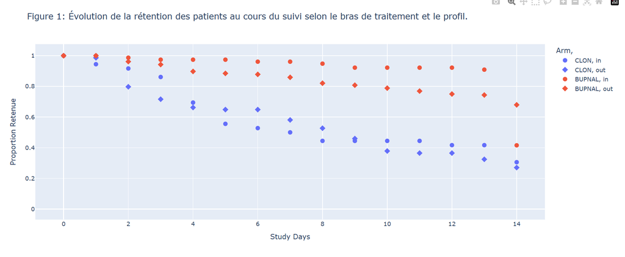

#### 4.4 Conclusion Génerale

- La Figure 1 montre une meilleure rétention sous BUPNAL par rapport à la Clonidine, chez les patients IN comme OUT.
- Cette tendance est cohérente avec les taux d’abstinence, numériquement plus élevés sous BUPNAL.
- Aucune différence statistiquement significative n’est observée (p-values > 0,05, IC 95 % incluant 0).
- Les écarts observés peuvent donc être attribués au hasard.
- Le déséquilibre des effectifs (ratio 2:1) a probablement réduit la puissance statistique, limitant la détection d’une - - différence réelle.